# Course 5, peer-graded assignment 1

## Loading and preprocessing the data

1. Load the data, and remove NAs from steps

```r
dt_raw <- read.csv("activity.csv", header = TRUE)
dt <- dt_raw[!(is.na(dt_raw$steps)),]
```

2. change date column data type from factor to character, and to Date.

```r
dt$date <- as.Date(as.character(dt$date),"%Y-%m-%d")
```

## What is mean total number of steps taken per day?

load the dplyr library

1. Calculate the total number of steps taken per day

```r
by_date <- group_by(dt, date)
stepbydate <- summarize(by_date, totalsteps=sum(steps))
```

2. histogram of the total number of steps taken per day

```
## stat_bin: binwidth defaulted to range/30. Use 'binwidth = x' to adjust this.
```

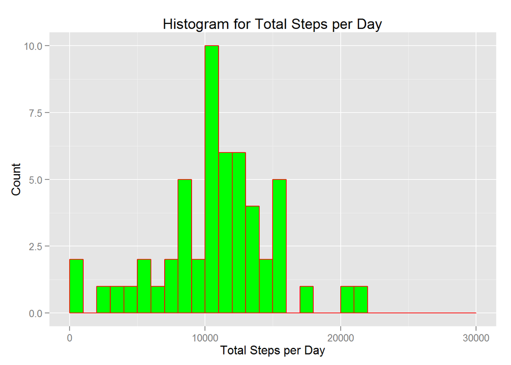

```r
library(ggplot2)
ggplot(stepbydate, aes(totalsteps)) + geom_histogram(col="red",fill="green") + labs(title="Histogram for Total Steps per Day", x="Total Steps per Day", y = "Count")+ scale_x_continuous(limits = c(0,30000))
```

```r
mean_step <- mean(stepbydate$totalsteps, na.rm=TRUE)
```

```r
median_step <- median(stepbydate$totalsteps, na.rm=TRUE)
```

answer: the median of the total number of steps taken per day is: 10765.

## What is the average daily activity pattern?

group data by interval, and calculate average steps in each interval, averaged across all days

```r
by_interval <- group_by(dt, interval)
stepbyinterval <- summarize(by_interval, avgsteps=mean(steps))
```

1. A time series plot of the 5-minute interval (x-axis) and the average number of steps taken, averaged across all days (y-axis)

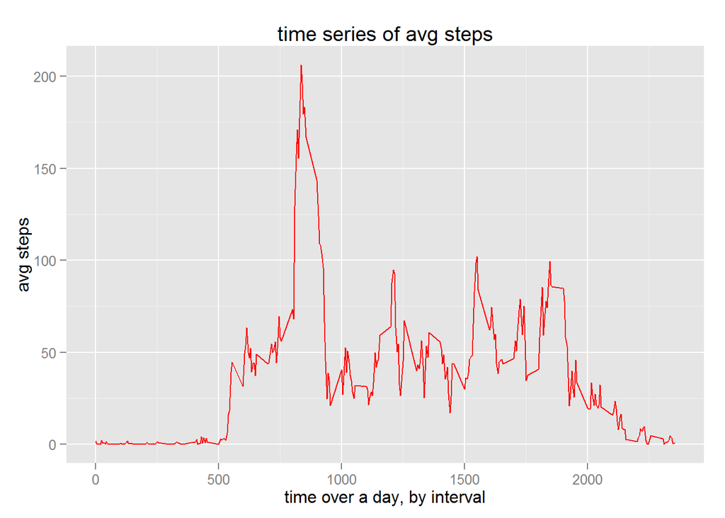

```r
ggplot(stepbyinterval, aes(interval,avgsteps)) + geom_line(col="red") + labs(title="time series of avg steps", x="time over a day, by interval", y = "avg steps")
```

2. Which 5-minute interval, on average across all the days in the dataset, contains the maximum number of steps?

```r
maxstep_interval <- stepbyinterval[which.max(stepbyinterval$avgsteps),1]
```

answer: On average across all the days in the dataset, the 5-minute interval at 835 contains the maximum number of steps.

## Imputing missing values

1. Calcualte and report the total number of missing values in the dataset

```r
n_missing<-sum(is.na(dt_raw$steps))
```

answer: The total number of missing values in the dataset is: 2304.

2. Devise a strategy for filling in all of the missing values in the dataset.

```r
def_step <- mean(dt_raw$steps,na.rm=TRUE)
```

assumption: Using the mean of the number of steps of the total original dataset for any missing values.

3. Create a new dataset that is equal to the original dataset but with the missing data filled

```r
dt_fill <- dt_raw
dt_fill[which(is.na(dt_fill$steps)),1] <- def_step
dt_fill$date <- as.Date(as.character(dt_fill$date),"%Y-%m-%d")
```

Calculate the new total number of steps taken per day

```r
by_date2 <- group_by(dt_fill, date)
stepbydate2 <- summarize(by_date2, totalsteps=sum(steps))
```

histogram of the total number of steps taken per day

```
## stat_bin: binwidth defaulted to range/30. Use 'binwidth = x' to adjust this.
```

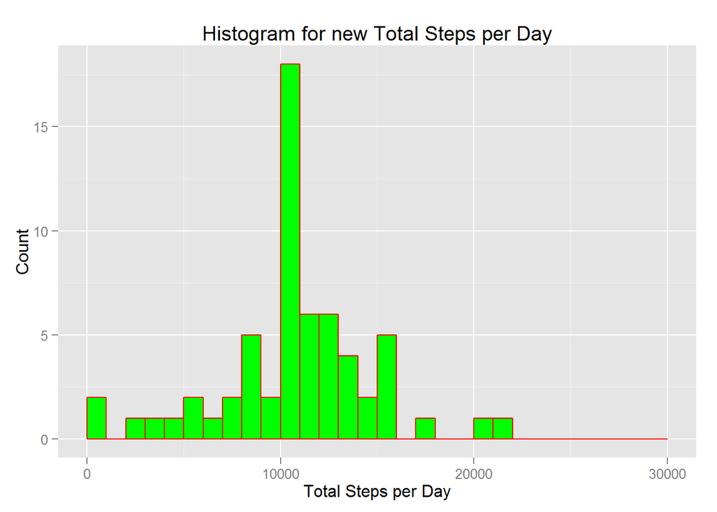

```r
library(ggplot2)
ggplot(stepbydate2, aes(totalsteps)) + geom_histogram(col="red",fill="green") + labs(title="Histogram for new Total Steps per Day", x="Total Steps per Day", y = "Count")+ scale_x_continuous(limits = c(0,30000))
```

```r
mean_step2 <- mean(stepbydate2$totalsteps, na.rm=TRUE)
```

```r
median_step2 <- median(stepbydate2$totalsteps, na.rm=TRUE)
```